# WM-Plakat: A new hope

Vincent Schmalor

27.12.2019

# Einleitung

Dieses Dokument stellt sowohl die Durchführung, als auch die Protokollierung des Vorhersagewettbewerbs dar. Die Aufgabenstellung besteht darin, ein Modell aus einem Grunddatensatz zu entwickeln und dieses Modell auf einen Anwendungsdatensatz anzuwenden. Dabei wird aus mehreren Einflussvariablen eine abhängige Variable geschätzt. Der konkrete Anwendungsfall ist ein Auszug aus einem Face-to-Face Interview über das Konsum- und Schenkverhalten zu Weihnachten. Das Grunddatenset beinhaltet 400 Beobachtungen mit 17 erklärenden Variablen und die abhängige Variable des geschätzten Budgets, die es im Anwendungsdatenset zu modellieren gilt. In dem folgenden Kapitel wird diese Aufgabe bearbeitet, indem zunächst ein Überblick über die Daten in einer explorativen Datenanalyse gegeben wird. Anhand verschiedener Analysen und der Untersuchung der semantischen Zusammenhänge wird dann eine Vorgehensweise erarbeitet und beschrieben. Das Ergebnis ist eine csv-Datei, die das Anwendungsdatenset mit der modellierten, abhängigen Variable beinhaltet. So wird eine Prognose über diese Variable für jede Beobachtung gegeben, für die das tatsächliche Budget nicht vorliegt. Eine Zusammenfassung der Ergebnisse findet sich auch auf dem Plakat der genannten Autoren.

# Vorbereitung des Datensets

1. Die folgende Operation weist den Spalten des Datensets die korrekten sprechenden Bezeichnungen zu, um sie im späteren Verlauf besser identifizeren zu können

```r
colnames(DST.raw) <- c("Beratung", "Angebote", "Bequemlichkeit", "Einkaufsatmosphaere", "Marken", "GPM", "Naehe", "Partner", "Eltern", "Verwandte", "Kommilitonen", "Kinder", "Freunde", "Arbeitskollegen", "GemNutz", "Alter", "Geschlecht", "Budget") #Vektor wird erstellt und auf die Spalten angewendet
```

2. Bevor die Daten verändert werden, wird an dieser Stelle die gesamte Stichprobe in mehrere Resamples gespeichert, um später etwa Bootstrap-Analysen durchführen zu können

```r
DS.RS1 <- resample(DST.raw)
DS.RS2 <- resample(DST.raw)
DS.RS3 <- resample(DST.raw)
```

3. Das Datenset beinhaltet einige Ausreißer, die im Vorfeld der Analyse gefiltert werden sollten. Ausreißer sind sicher auch in der Population vorhanden. Da diese jedoch nicht modelliert werden können, werden sie für die Erstellung des Modells gefiltert.

```r
DST.clean <- filter(DST.raw, Budget > 30) #Untere Elemente filtern. Realistische Werte sind ab 30€ zu erwarten
OL.DS.raw <- boxplot.stats(DST.clean$Budget)$out #Boxplotergebnisse verwenden, um Ausreißer zu speichern
paste("Ausreißer: ", paste(OL.DS.raw, collapse=", ")) #Ausreißerwerte ausgeben
```

```
## [1] "Ausreißer:  1500, 2500, 1500, 1500, 3100, 3500, 1500, 1300, 1400, 2500, 1500, 1500, 1500, 1500, 2100, 1500, 2500, 2000, 1285, 1500"
```

```r
DST.clean <- DST.clean %>% filter(!(Budget %in% OL.DS.raw)) #Filter anwenden
```

4. Im Folgenden werden zwei abgeleitete Kennzahlen eingeführt. Die Kennzahlen leiten sich aus den Personen ab, die beschenk werden, und welche Ansprüche die Schenkenden an die Geschenke haben. -Anzahl der Geschenke: Die Vermutung besteht, dass ein Zusammenhang ziwschen der Gesamtanzahl an beschenkten Personen und dem geplanten Budget besteht. Die Summe der beschenkten Personen wird daher im Folgenden als Anzahl der Geschenke verwendet. -Wertschätzung: Die Vermutung besteht, dass ein Zusdammenhang zwischen der Summe der als wichtig beziechneten Geschenk- und Dienstleistungseigenschaften und dem geplanten Budget besteht. Die Summe der Wertschätzungsgrade wird daher im Folgenden als Wertschätzung verwendet.

```r
DST.extra <- mutate(DST.clean, GesAnz = Partner + Eltern + Verwandte + Kommilitonen + Kinder + Freunde + Arbeitskollegen + GemNutz)
DST.extra <- mutate(DST.extra, Wertsch = Beratung + Angebote + Bequemlichkeit + Einkaufsatmosphaere + Marken + GPM + Naehe)
```

5. Alle Variablen bis auf das Alter, das Budget und die beiden neu eingeführten sind tatsächlich kategoriell, werden von R aber als numerisch klassifiziert. Das ist für viele Analysen sinnvoll, einige Visualisierungen verlangen aber den Datentyp Faktor. Für den Fall, dass bei Analysen kategorielle Variablen untersucht werden sollen, werden die kategoriellen Variablen als solche gekennzeichnet.

```r
DST.num <- DST.extra
cols <- c("Beratung", "Angebote", "Bequemlichkeit", "Einkaufsatmosphaere", "Marken", "GPM", "Naehe"
          , "Partner", "Eltern", "Verwandte", "Kommilitonen", "Kinder", "Freunde", "Arbeitskollegen", "GemNutz"
          , "Geschlecht") #Faktorspalten auswählen
DST.cat <- DST.extra #Dataset auf neue Variable kopieren
DST.cat[cols] <- lapply(DST.cat[cols], factor) #Faktorspalten setzen
```

# Explorative Datenanalyse

## Verteilungen untersuchen

Im Folgenden werden die Daten verschieden dargestellt, um einen Überblick über die Verteilungen zu bekommen.

1. gf_histogram

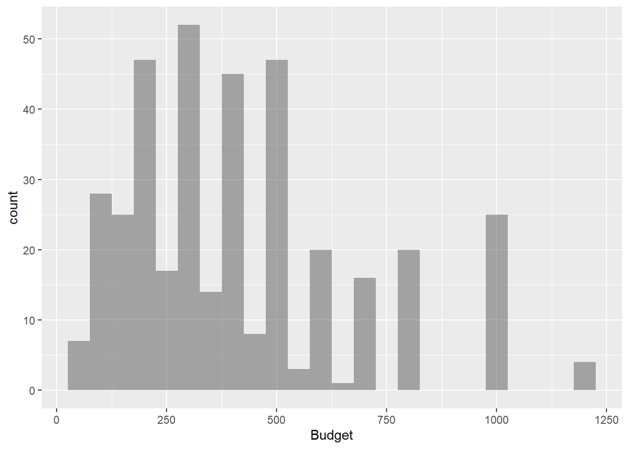

2. gf_violin

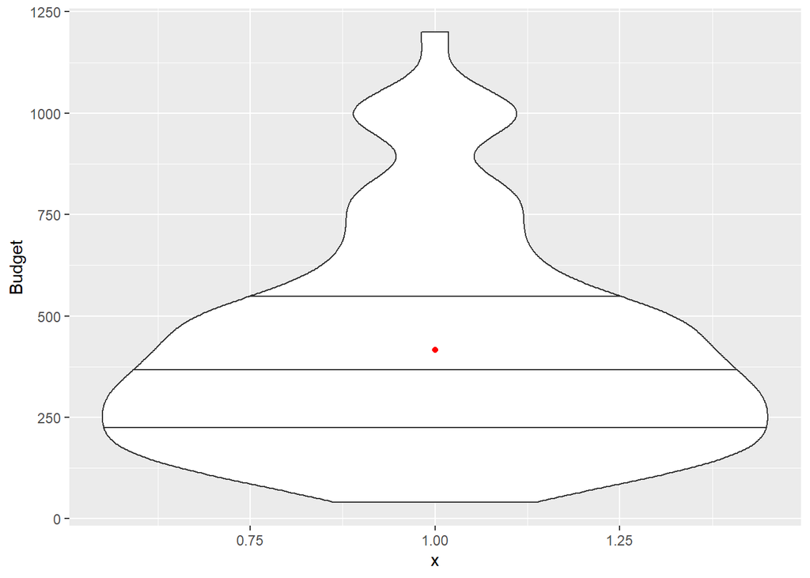

3. gf_boxplot

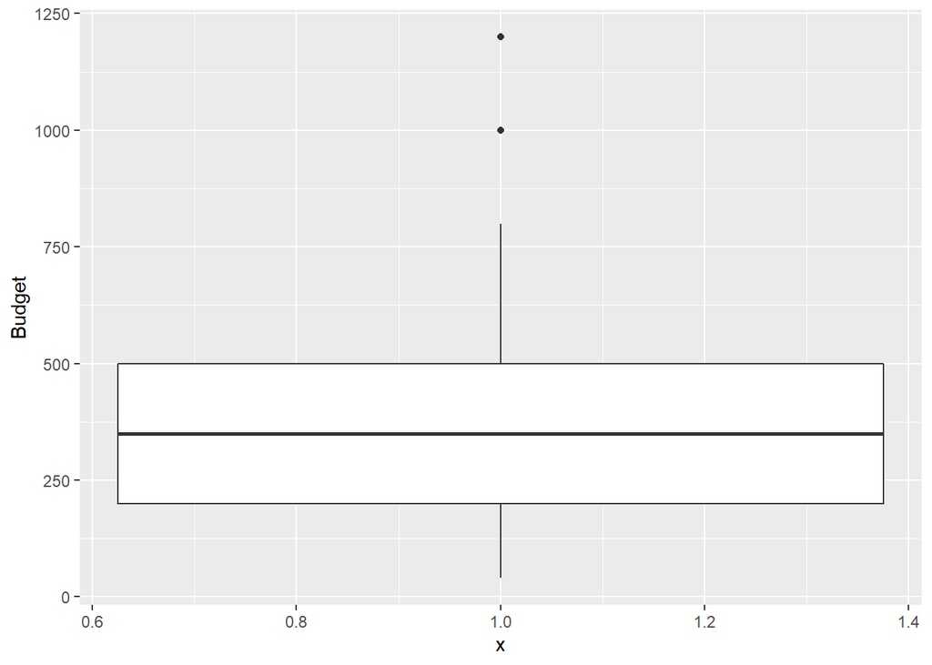

## Zusammenhänge finden

Nachdem die Grunddatenmenge visualisiert wurde, müssen für die Erstellung eines Modells die Zusammenhänge zwischen den Variablen untersucht werden. Insbesondere die Relationen zwischen allen Variablen und dem Budget sind hierbei von Relevanz. Mit der Funktion “rcorr” wird eine Korrelationsmatrix erstellt. Anhand dieser Korrelkationsmatrix lassen sich Relationen und P-Werte ablesen.

```r
DST.mat <- as.matrix(data.frame(DST.num)) #Konvertierung in verwendbares Format
CMT <- rcorr(DST.mat, type = "pearson") #Erstellung der Korrelationsmatrix
```

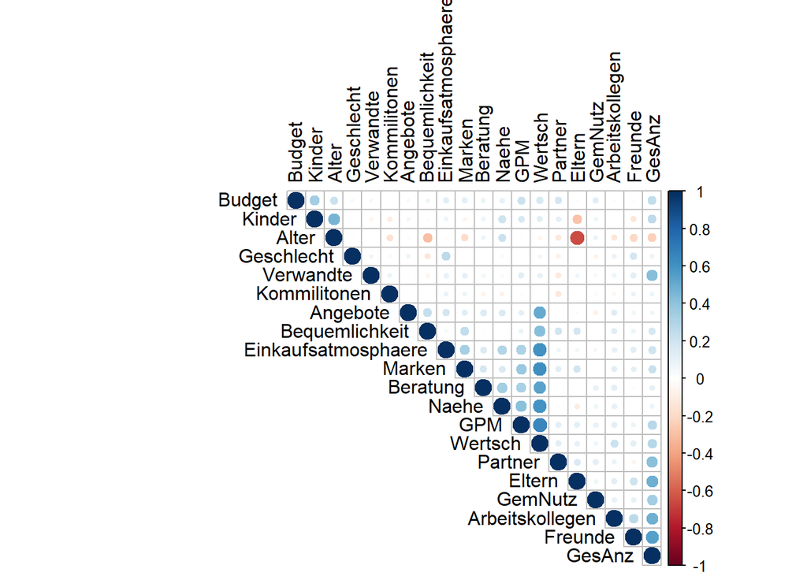

```r
corrplot(CMT$r, type = "upper", order = "hclust", tl.col = "black", sig.level = 0.01) #Visualisierung der Korrelationen aller Variablen untereinander
```

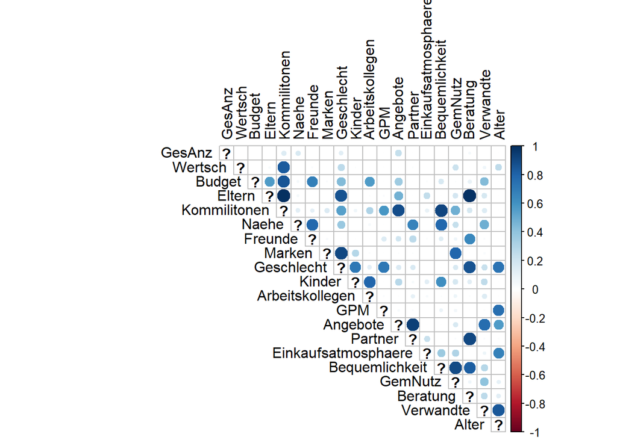

```r
corrplot(CMT$P, type = "upper", order = "hclust", tl.col = "black", sig.level = 0.01) #Visualisierung der P-Werte aller Korrelationen zwischen allen Variablen
```

Erwartungsgemäß bestehen starke Korrelationen zwischen Wertschätzung und deren Einflussvariablen sowie der Anzahl der Geschenke und deren Einflussfaktoren. Eine starke negative Korrelation besteht auch zwischen dem Alter und der Frage, ob Eltern beschenkt werden. Diese Erkenntnisse sind sicher einerseits interessant, andererseits auch erwartbar, aber nicht relevant in der Modellierung des Budgets. Da es keine starken Ausprägungen in den Relationen zwischen Budget und anderen Variablen gibt, wird in der nächsten Grafik der P-Wert je Korrelation dargerstellt.

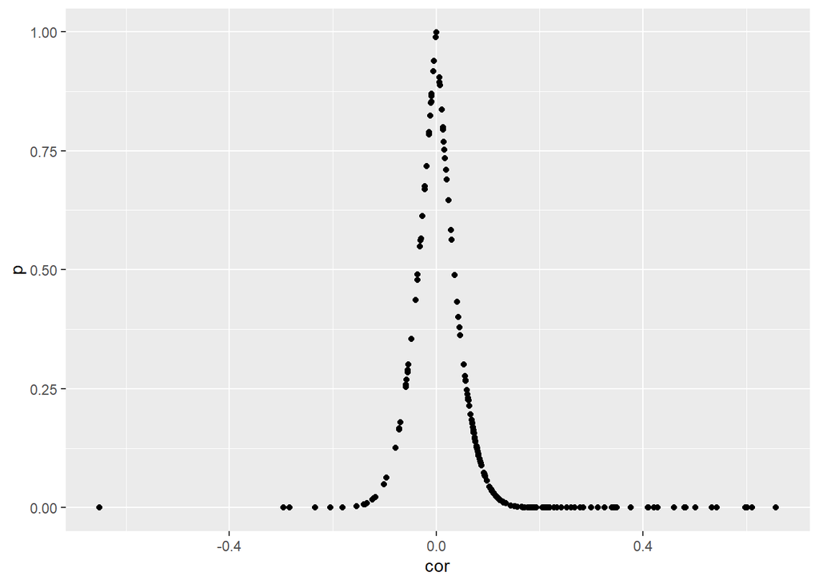

```r
CMT.tbl <- flattenCorrMatrix(CMT$r, CMT$P) #Tabellen joinen, um eine Tabelle zu erhalten
gf_point(p ~ cor, data = CMT.tbl) #Visualisierung
```

Wie vermutet weisen viele Korrelationen einen viel zu hohen P-Wert aus, als dass sie in der Modellierung des Budgets verwendet werden könnten. Eine Filterung auf einen angemessenen P-Wert ist daher unerlässlich.

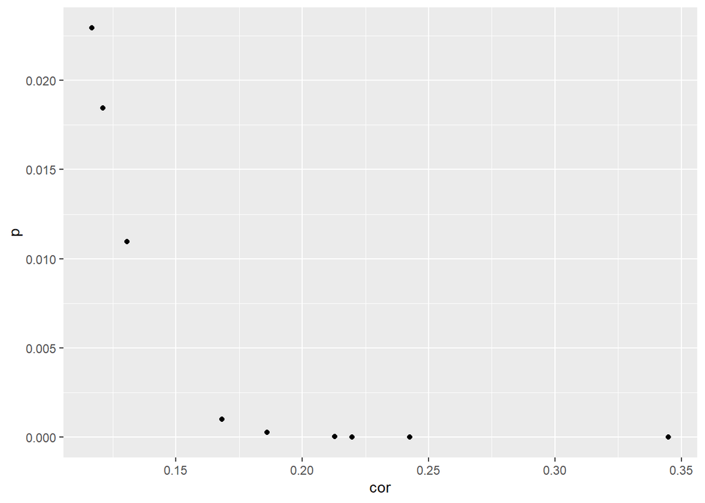

```r
CMT.tbl.f <- filter(CMT.tbl, p < 0.03 & (row == "Budget" | column == "Budget"))
gf_point(p ~ cor, data = CMT.tbl.f)
```

```r
CMT.tbl.f
```

```
##                   row  column       cor                    p
## 1 Einkaufsatmosphaere  Budget 0.1209947 0.018453103487469535
## 2              Marken  Budget 0.1168220 0.022932215428778102
## 3                 GPM  Budget 0.2128488 0.000029407348239641
## 4             Partner  Budget 0.1860446 0.000270757664015076
## 5              Kinder  Budget 0.3448485 0.000000000005047518
## 6             GemNutz  Budget 0.1305671 0.010947326592058548
## 7               Alter  Budget 0.2197324 0.000015854409149529
## 8              Budget  GesAnz 0.2425775 0.000001766615588927
## 9              Budget Wertsch 0.1682677 0.001007301360662405
```

Die Grafik zeigt die relativen Positionierungen von P-Werten und Korrelationsstärken. Sie korrespondieren mit den Werten der Tabelle. Nun, da die relevanten Einflussfaktoren isoliert wurden, werden ausschließlich diese Variablen weiterverwendet.

## Lineare Regressionen der relevanten Einflussvariablen

Im vorigen Kapitel wurden relevante Korrelationen ausgewählt. Im Folgenden werden diese mit je einer Visualisierung in Form einer linearen Regression verdeutlicht.

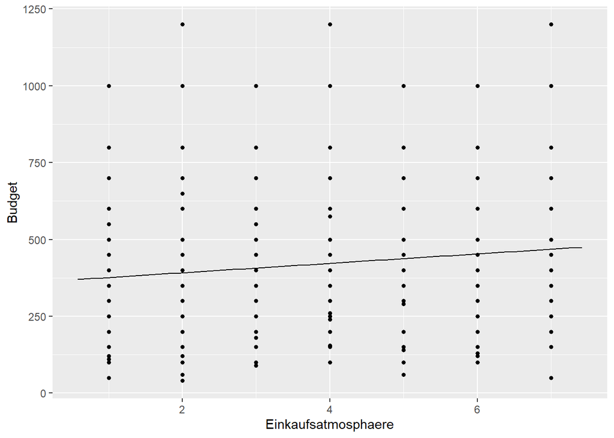

```
##
## Call:
## lm(formula = Budget ~ Einkaufsatmosphaere, data = DST.num)
##
## Residuals:
##     Min      1Q  Median      3Q     Max
## -418.42 -191.75  -57.08  123.58  808.25
##
## Coefficients:
##                     Estimate Std. Error t value            Pr(>|t|)
## (Intercept)          361.083     26.529  13.611 <0.0000000000000002 ***
## Einkaufsatmosphaere   15.334      6.479   2.367              0.0185 *
## ---
## Signif. codes:  0 '***' 0.001 '**' 0.01 '*' 0.05 '.' 0.1 ' ' 1
##
## Residual standard error: 257 on 377 degrees of freedom
## Multiple R-squared:  0.01464,    Adjusted R-squared:  0.01203
## F-statistic: 5.601 on 1 and 377 DF,  p-value: 0.01845
```

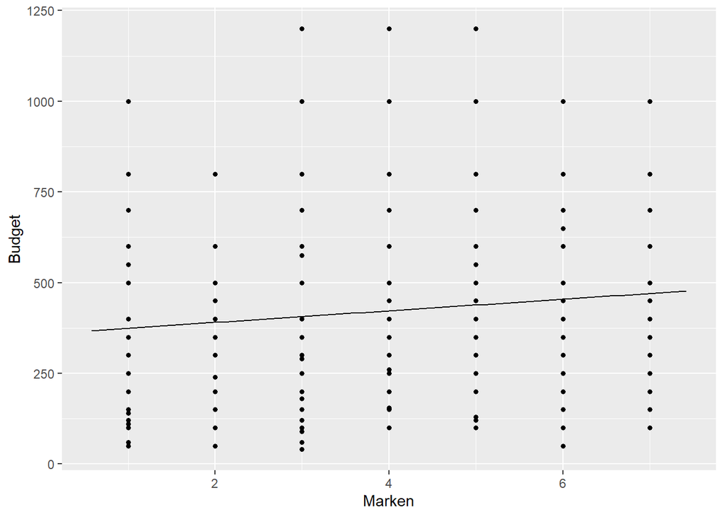

```
##
## Call:
## lm(formula = Budget ~ Marken, data = DST.num)
##
## Residuals:
##     Min      1Q  Median      3Q     Max
## -404.45 -197.50  -56.52  125.44  793.48
##
## Coefficients:
##             Estimate Std. Error t value            Pr(>|t|)
## (Intercept)  358.584     28.221  12.706 <0.0000000000000002 ***
## Marken        15.978      6.996   2.284              0.0229 *
## ---
## Signif. codes:  0 '***' 0.001 '**' 0.01 '*' 0.05 '.' 0.1 ' ' 1
##
## Residual standard error: 257.2 on 377 degrees of freedom
## Multiple R-squared:  0.01365,    Adjusted R-squared:  0.01103
## F-statistic: 5.216 on 1 and 377 DF,  p-value: 0.02293
```

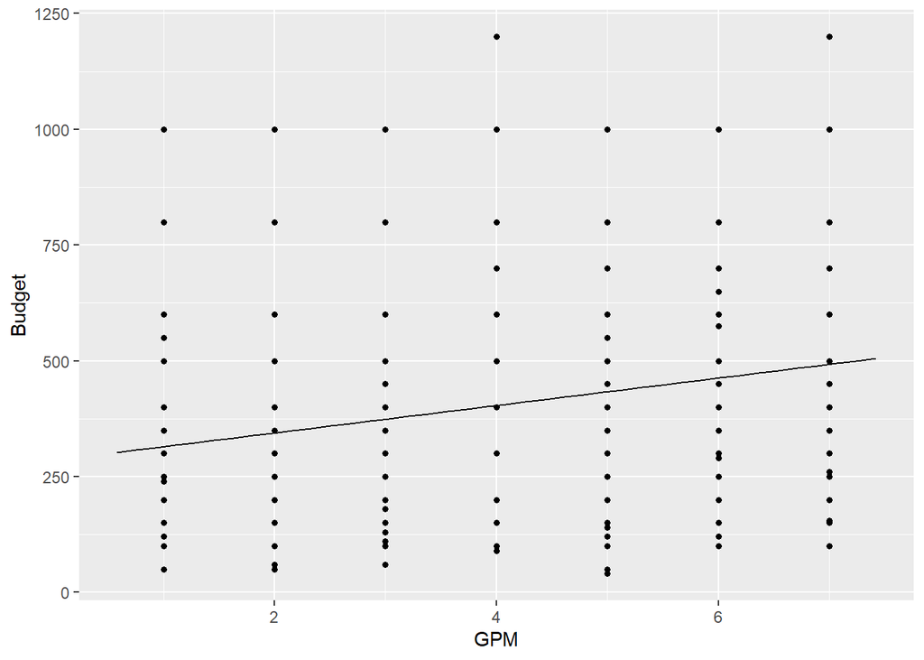

```
##
## Call:
## lm(formula = Budget ~ GPM, data = DST.num)
##
## Residuals:
##     Min      1Q  Median      3Q     Max
## -393.54 -192.84  -63.19  114.14  796.12
##
## Coefficients:
##             Estimate Std. Error t value             Pr(>|t|)
## (Intercept)   285.28      33.43   8.534 0.000000000000000349 ***
## GPM            29.65       7.01   4.230 0.000029407348239604 ***
## ---
## Signif. codes:  0 '***' 0.001 '**' 0.01 '*' 0.05 '.' 0.1 ' ' 1
##
## Residual standard error: 253 on 377 degrees of freedom
## Multiple R-squared:  0.0453, Adjusted R-squared:  0.04277
## F-statistic: 17.89 on 1 and 377 DF,  p-value: 0.00002941
```

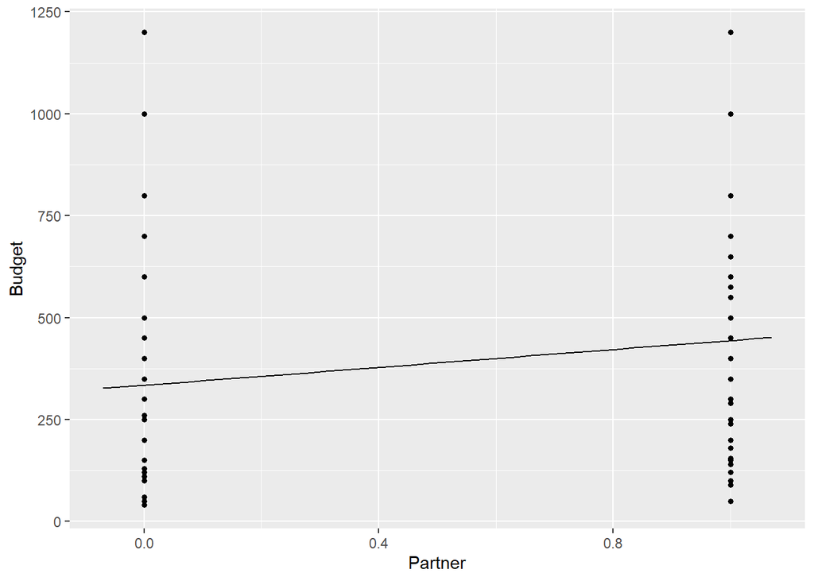

```
##
## Call:
## lm(formula = Budget ~ Partner, data = DST.num)
##
## Residuals:
##     Min      1Q  Median      3Q     Max
## -393.91 -193.91  -43.91  156.09  865.82
##
## Coefficients:
##             Estimate Std. Error t value             Pr(>|t|)
## (Intercept)   334.18      25.70  13.003 < 0.0000000000000002 ***
## Partner       109.73      29.85   3.677             0.000271 ***
## ---
## Signif. codes:  0 '***' 0.001 '**' 0.01 '*' 0.05 '.' 0.1 ' ' 1
##
## Residual standard error: 254.4 on 377 degrees of freedom
## Multiple R-squared:  0.03461,    Adjusted R-squared:  0.03205
## F-statistic: 13.52 on 1 and 377 DF,  p-value: 0.0002708
```

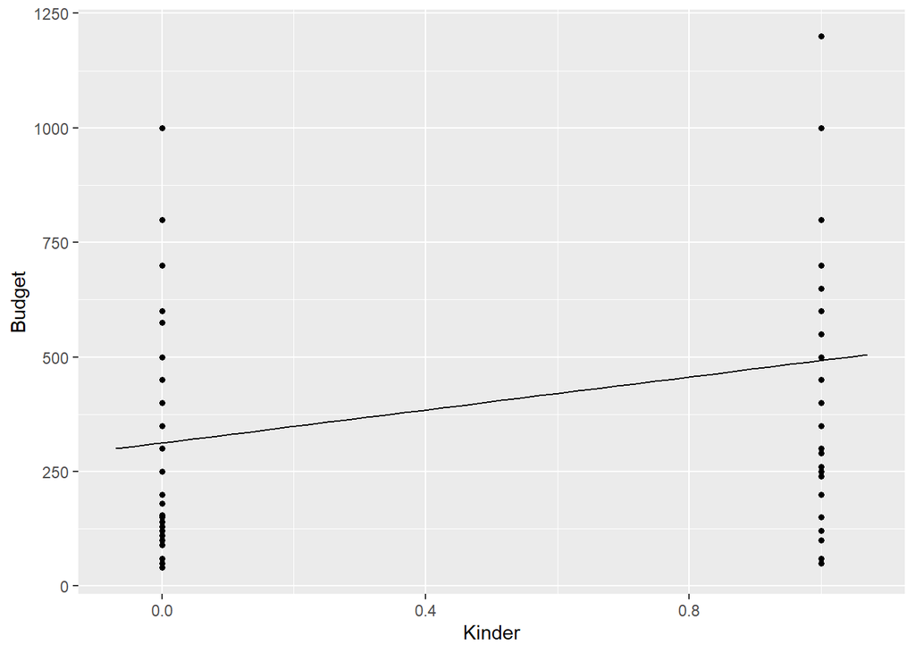

```
##
## Call:
## lm(formula = Budget ~ Kinder, data = DST.num)
##
## Residuals:
##     Min      1Q  Median      3Q     Max
## -442.49 -177.47  -42.49  107.51  707.51
##
## Coefficients:
##             Estimate Std. Error t value             Pr(>|t|)
## (Intercept)   312.47      19.10  16.363 < 0.0000000000000002 ***
## Kinder        180.02      25.24   7.133     0.00000000000505 ***
## ---
## Signif. codes:  0 '***' 0.001 '**' 0.01 '*' 0.05 '.' 0.1 ' ' 1
##
## Residual standard error: 243 on 377 degrees of freedom
## Multiple R-squared:  0.1189, Adjusted R-squared:  0.1166
## F-statistic: 50.88 on 1 and 377 DF,  p-value: 0.000000000005048
```

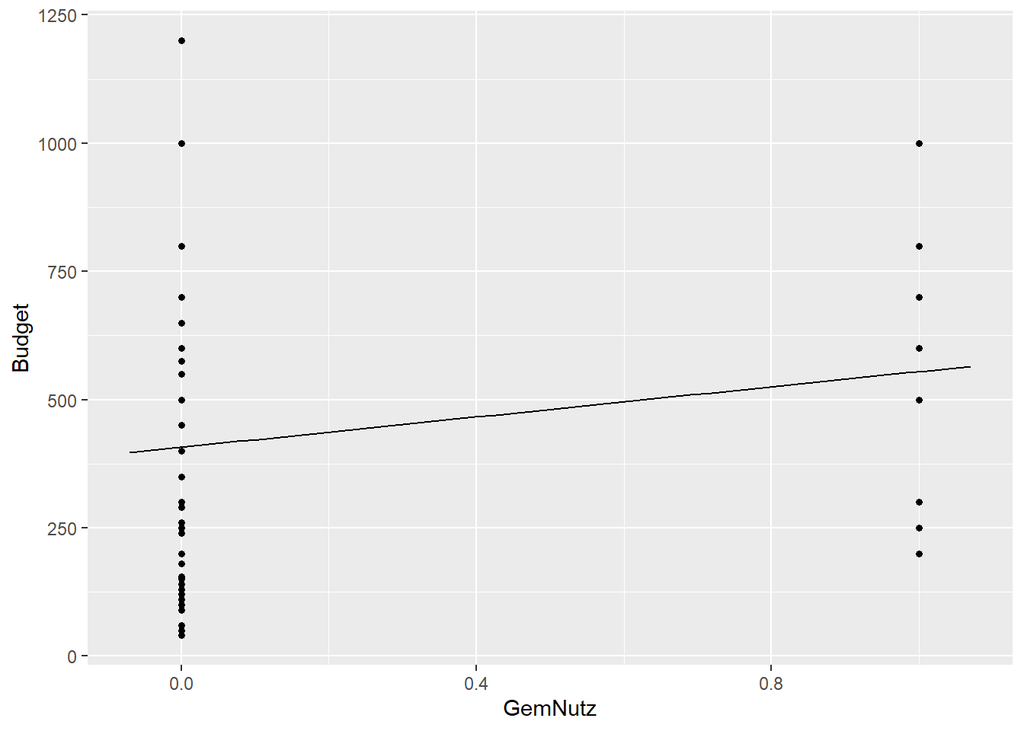

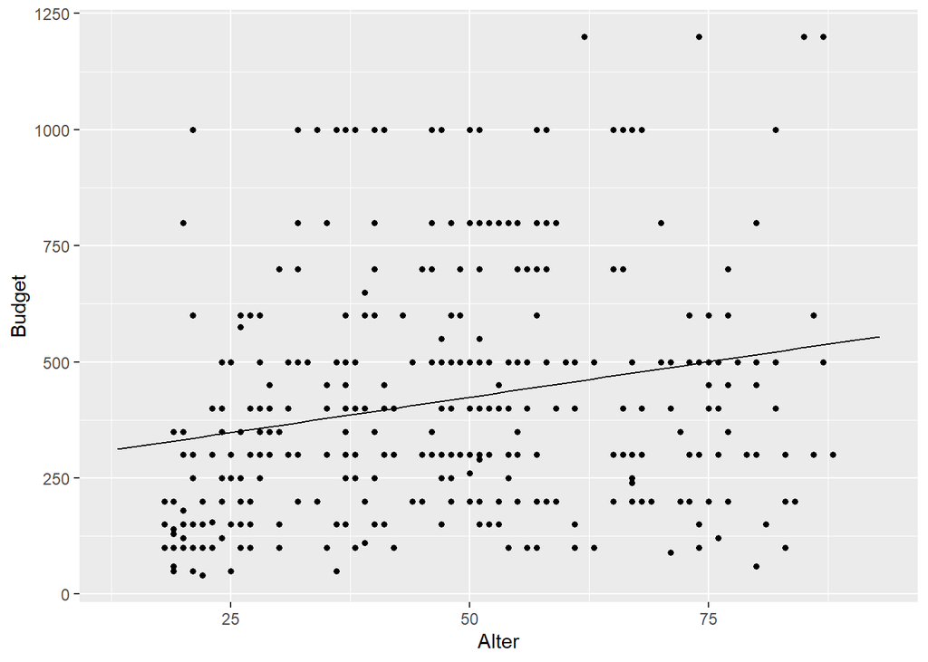

```
##
## Call:
## lm(formula = Budget ~ Alter, data = DST.num)
##
## Residuals:
##     Min      1Q  Median      3Q     Max
## -455.55 -192.46  -48.05  112.36  739.27
##
## Coefficients:
##             Estimate Std. Error t value          Pr(>|t|)
## (Intercept) 271.9164    35.3115   7.701 0.000000000000121 ***
## Alter         3.0454     0.6964   4.373 0.000015854409150 ***
## ---
## Signif. codes:  0 '***' 0.001 '**' 0.01 '*' 0.05 '.' 0.1 ' ' 1
##
## Residual standard error: 252.6 on 377 degrees of freedom
## Multiple R-squared:  0.04828,    Adjusted R-squared:  0.04576
## F-statistic: 19.13 on 1 and 377 DF,  p-value: 0.00001585
```

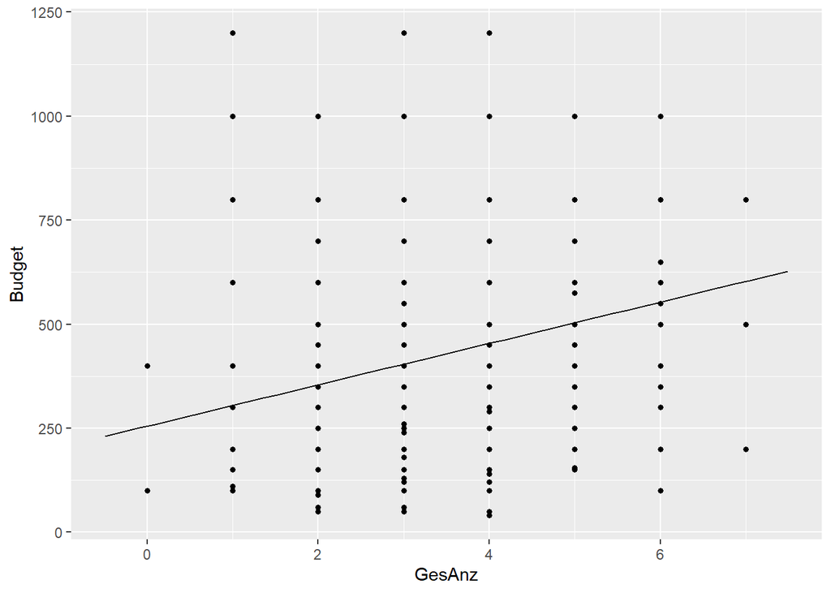

```
##
## Call:
## lm(formula = Budget ~ GesAnz, data = DST.num)
##
## Residuals:
##    Min     1Q Median     3Q    Max
## -453.2 -154.6  -54.0   96.0  895.5
##
## Coefficients:
##             Estimate Std. Error t value         Pr(>|t|)
## (Intercept)   254.82      35.53   7.172 0.00000000000393 ***
## GesAnz         49.72      10.24   4.855 0.00000176661559 ***
## ---
## Signif. codes:  0 '***' 0.001 '**' 0.01 '*' 0.05 '.' 0.1 ' ' 1
##
## Residual standard error: 251.2 on 377 degrees of freedom
## Multiple R-squared:  0.05884,    Adjusted R-squared:  0.05635
## F-statistic: 23.57 on 1 and 377 DF,  p-value: 0.000001767
```

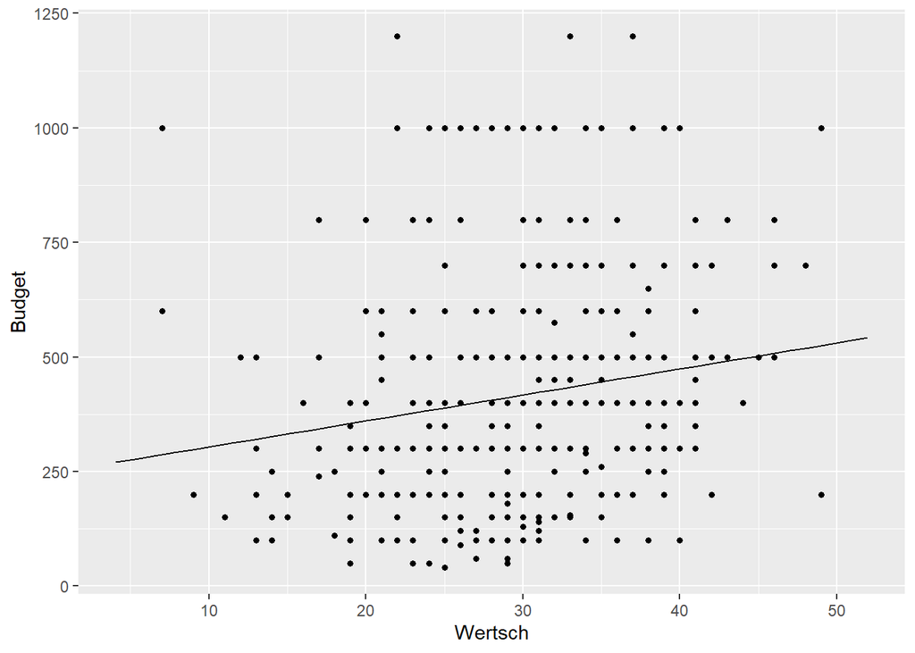

```
##
## Call:
## lm(formula = Budget ~ Wertsch, data = DST.num)
##
## Residuals:
##     Min      1Q  Median      3Q     Max
## -374.04 -192.28  -55.93  118.53  828.13
##
## Coefficients:
##             Estimate Std. Error t value   Pr(>|t|)
## (Intercept)  246.983     52.519   4.703 0.00000361 ***
## Wertsch        5.676      1.713   3.314    0.00101 **
## ---
## Signif. codes:  0 '***' 0.001 '**' 0.01 '*' 0.05 '.' 0.1 ' ' 1
##
## Residual standard error: 255.2 on 377 degrees of freedom
## Multiple R-squared:  0.02831,    Adjusted R-squared:  0.02574
## F-statistic: 10.99 on 1 and 377 DF,  p-value: 0.001007
```

# Erstellung des Modells

In den vorigen Kapiteln wurde das Datenset bearbeitet, veranschaulicht und es wurden die relevanten Einflussfaktoren auf das Budget der befragten Personen identifiziert. Um das Budget zu modellieren wird an dieser Stelle eine multiple Regression mit den identifizierten Einflussfaktoren vorgenommen. Anhand dieser Regressionsanalyse ist es möglich, ein unvollständiges Datenset zu extrapolieren. In das Modell fließen ausschlißlich die relevantesten Variablen ein, um ein Overfitting zu vermeiden und gegebenenfalls zufällige Einflüsse zu filtern. Da selbst unter den ausgewählten Einflüssen noch immer hohe P-Werte bestehen, werden in der Regression nicht alle Einflüsse berücksichtigt. Das Budget wird anhand des Alters, der Güte der Produkte und Marken, der Anzahl an beschenkten Personen und der Tatsache, ob Kinder und Partner beschenkt werden, erstellt. Diese Variablen modellieren daher in diesem Fall das Budget.

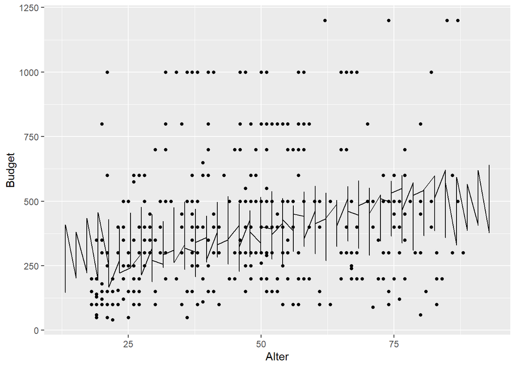

```r
lm.Gesamt <- lm(
  Budget ~ Alter + GPM + GesAnz + Partner + Kinder , data = DST.num
  ) #Modell erstellen
plotModel(lm.Gesamt) #Modell visualisieren
```

```r
summary(lm.Gesamt) #Modell in Zahlen ausdrücken
```

```
##
## Call:
## lm(formula = Budget ~ Alter + GPM + GesAnz + Partner + Kinder,
##     data = DST.num)
##
## Residuals:
##     Min      1Q  Median      3Q     Max
## -478.77 -155.08  -44.62  109.26  766.27
##
## Coefficients:
##             Estimate Std. Error t value Pr(>|t|)
## (Intercept)   13.882     58.109   0.239  0.81132
## Alter          2.505      0.798   3.139  0.00183 **
## GPM           16.965      6.802   2.494  0.01305 *
## GesAnz        32.608     11.874   2.746  0.00632 **
## Partner       63.387     30.170   2.101  0.03631 *
## Kinder        98.857     30.237   3.269  0.00118 **
## ---
## Signif. codes:  0 '***' 0.001 '**' 0.01 '*' 0.05 '.' 0.1 ' ' 1
##
## Residual standard error: 234.4 on 373 degrees of freedom
## Multiple R-squared:  0.1895, Adjusted R-squared:  0.1787
## F-statistic: 17.44 on 5 and 373 DF,  p-value: 0.000000000000001579
```

Das Ergebnis zeigt, dass auch in Kobination der Variablen in einem Modell weiterhin hohe Signifikanzniveaus bestehen. Das Modell erklärt knapp 18% der Varianz. Einflüsse, wie etwa der sozioökoniomische Status der Personen würden die Güte des Modells vermutlich steigern.

# Validierung des Modells

Um die Güte des Modells zu prüfen, wird das Modell auf die resampleten Daten angewandt und mit dem Durchschnitt verglichen. Die Methodik ist hier zwei mal gelistet und wird vier mal angewandt.

```r
#Mean erstellen
DST.AVG <- DST.raw %>% mutate(Budget2 = mean(DST.raw$Budget)) #Durchschnitt berechnen
DST.AVG <- DST.AVG %>% mutate(SQDiff = (Budget - Budget2)^2) #Differenzen berechnen
avg.diff <- sum(DST.AVG$SQDiff) #Differenzen summieren
#paste("Trainingsdaten: Die quadrierte Differenz der tatsächlichen Werte zum Durchschnitt beträgt ", avg.diff) #Differenz ausgeben
#Modell anwenden
DST.erglm <- predict.lm(lm.Gesamt, newdata = DST.extra, interval="prediction") #Modell anwenden
DST.erglm <- head(matrix(DST.erglm), n=400) #Ergebnis kürzen
DST.pred <- DST.raw %>% mutate(Budget2 = DST.erglm) #Ergebnis anfügen
DST.pred <- DST.pred  %>% mutate(SQDiff = (Budget - Budget2)^2) #Differenzen berechnen
diff.DST.pred <- sum(DST.pred$SQDiff) #Differenzen summieren
#paste("Trainingsdaten: Die quadrierte Differenz der tatsächlichen Werte zum Modell beträgt ", diff.DST.pred) #Differenz ausgeben
```

```r
#Mean erstellen
DS.RS1.AVG <- DS.RS1 %>% mutate(Budget2 = mean(DST.raw$Budget)) #Durchschnitt berechnen
DS.RS1.AVG <- DS.RS1.AVG %>% mutate(SQDiff = (Budget - Budget2)^2) #Differenzen berechnen
diff.DS.RS1.AVG <- sum(DS.RS1.AVG$SQDiff) #Differenzen summieren
#paste("Resample 1: Die quadrierte Differenz der tatsächlichen Werte zum Durchschnitt beträgt ", diff.DS.RS1.AVG) #Differenz ausgeben
DS.RS1.extra <- mutate(DS.RS1, GesAnz = Partner + Eltern + Verwandte + Kommilitonen + Kinder + Freunde + Arbeitskollegen + GemNutz) #Geschenkanzahl hinzufügen
DS.RS1.extra <- mutate(DS.RS1.extra, Wertsch = Beratung + Angebote + Bequemlichkeit + Einkaufsatmosphaere + Marken + GPM + Naehe) #Wertschätzung hinzufügen
DS.RS1.erglm <- predict.lm(lm.Gesamt, newdata = DS.RS1.extra, interval="prediction") #Modell anwenden
DS.RS1.erglm <- head(matrix(DS.RS1.erglm), n=400) #Ergebnis kürzen
DS.RS1.pred <- DS.RS1.extra %>% mutate(Budget2 = DS.RS1.erglm) #Ergebnisanfügen
DS.RS1.pred <- DS.RS1.pred  %>% mutate(SQDiff = (Budget - Budget2)^2) #Differenzen berechnen
diff.DS.RS1.pred <- sum(DS.RS1.pred$SQDiff) #Differenzen summieren
#paste("Resample 1: Die quadrierte Differenz der tatsächlichen Werte zum Durchschnitt beträgt ", diff.DS.RS1.pred)
```

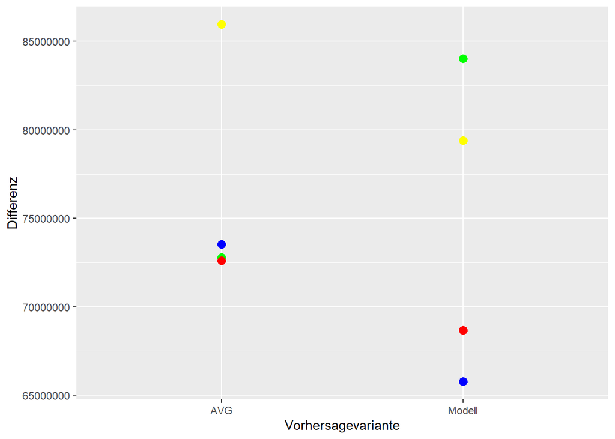

Die Grafik zeigt, dass das Modell in der Mehrzahl der Fälle unter dem Nullmodell liegt.

# Erstellung der Ergebnisse

Wie in der Einleitung beschrieben soll das Modell auf ein Datenset angewendet werden, das keine Budgetwerte besitzt. Das erfolgt nun in den folgenden Schritten.

```r
DSA.raw <- read.csv2("sources/Anwendungsdaten.csv")
colnames(DSA.raw) <- c("Beratung", "Angebote", "Bequemlichkeit", "Einkaufsatmosphaere", "Marken", "GPM", "Naehe", "Partner", "Eltern", "Verwandte", "Kommilitonen", "Kinder", "Freunde", "Arbeitskollegen", "GemNutz", "Alter", "Geschlecht") #Vektor wird erstellt und auf die Spalten angewendet
DSA.extra <- mutate(DSA.raw, GesAnz = Partner + Eltern + Verwandte + Kommilitonen + Kinder + Freunde + Arbeitskollegen + GemNutz)
DSA.extra <- mutate(DSA.extra, Wertsch = Beratung + Angebote + Bequemlichkeit + Einkaufsatmosphaere + Marken + GPM + Naehe)
DSA.erglm <- predict.lm(lm.Gesamt, newdata = DSA.extra, interval="prediction") #Modell anwenden
DSA.erglm <- head(matrix(DSA.erglm), n= 600)
DSA.fin <- mutate(DSA.extra, Budget = DSA.erglm)
write.csv2(DSA.fin, "TESTPrognose_Vincent_Schmalor_Hendrick_Kaiser_Lukas_Kueppers.csv")
```

# Untersuchung der Ergebnisse

## Übersicht

```
##       min       Q1   median       Q3     max     mean       sd   n missing
##  116.0586 343.5556 428.3234 508.3975 650.802 421.1625 107.2871 600       0
```

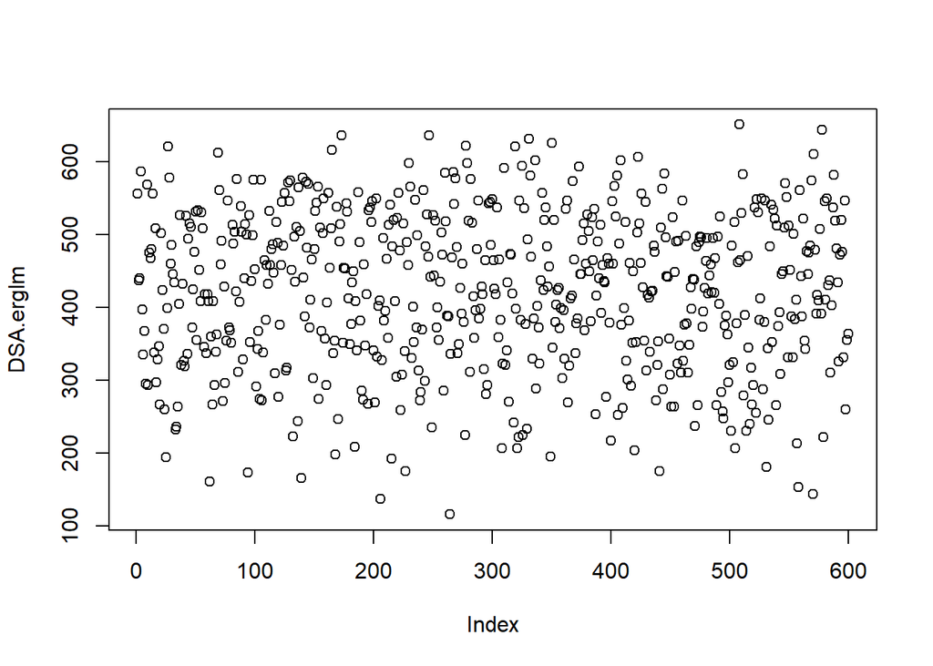

## Histogramme

[figure not shown]

## Punktwolken

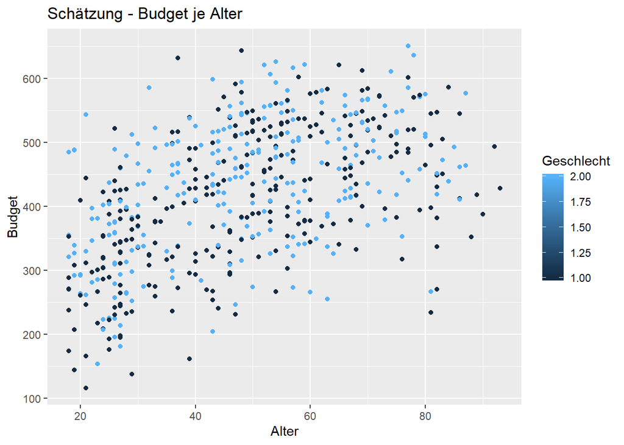

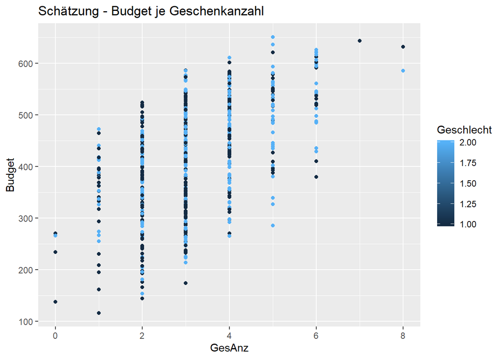